# Metric Graph Low-Pass: Single 1D Two-Gaussian Smoke Benchmark

## 1 Purpose

This development smoke benchmark compares a small parameter sweep of `fit.metric.graph.lowpass()` against a default-style `fit.rdgraph.regression()` baseline on one fixed 1D regression problem.

The target signal is a scaled two-Gaussian mixture on `[0, 1]`; the observations are `n = 250` uniformly sampled points with additive Gaussian noise. The metric low-pass fits use a symmetric 1D kNN graph with metric edge lengths `abs(x_i - x_j)`.

The rdgraph baseline is fit on the same `X`, `y`, and required `k`, but first uses `create.sknn.graph(..., connect.components = TRUE)` to add component-MST bridge edges when the native symmetric kNN graph is disconnected. The repaired graph is then passed to `fit.rdgraph.regression()` as a precomputed graph. This keeps the baseline fit available while making the repair explicit in the report.

The metric low-pass sweep interprets `weight.list` as metric edge lengths $\ell_{ij}$, not conductances. Each metric fit transforms lengths into conductances $c_{ij}$ before constructing the graph Laplacian. The conductance rules used here are:

$$c_{ij} = (\ell_{ij} + \epsilon)^{-\alpha}$$

for `inverse.length.power`,

$$c_{ij} = \exp(-\ell_{ij}/\sigma)$$

for `exp.length`,

$$c_{ij} = \exp(-\ell_{ij}^{2}/\sigma^{2})$$

for `exp.length.squared`, and

$$c_{ij} = \exp\{-\ell_{ij}^{2}/(\sigma_i\sigma_j)\}$$

for `self.tuned.gaussian`.

## 2 Helpers

```r
scaled_two_gaussian <- function(x,
                                means = c(0.30, 0.68),
                                sds = c(0.055, 0.085),
                                weights = c(1.0, 0.78)) {
  y <- weights[1] * dnorm(x, means[1], sds[1]) +
    weights[2] * dnorm(x, means[2], sds[2])
  y / max(y)
}

build_knn_graph_1d <- function(x, k, edge.length.floor = 1e-8) {
  n <- length(x)
  k <- min(max(as.integer(k), 1L), n - 1L)
  ord <- order(x)
  rank.of <- integer(n)
  rank.of[ord] <- seq_len(n)
  edges <- matrix(integer(0), ncol = 2)

  for (i in seq_len(n)) {
    rank.i <- rank.of[i]
    candidate.ranks <- seq.int(max(1L, rank.i - k), min(n, rank.i + k))
    candidates <- ord[candidate.ranks]
    candidates <- candidates[candidates != i]
    if (length(candidates) > k) {
      candidates <- candidates[order(abs(x[candidates] - x[i]))[seq_len(k)]]
    }
    if (length(candidates) > 0) {
      edges <- rbind(edges, cbind(rep(i, length(candidates)), candidates))
    }
  }

  edges <- unique(t(apply(edges, 1L, sort)))
  adj <- vector("list", n)
  weights <- vector("list", n)
  for (i in seq_len(n)) {
    adj[[i]] <- integer(0)
    weights[[i]] <- numeric(0)
  }
  for (e in seq_len(nrow(edges))) {
    i <- edges[e, 1L]
    j <- edges[e, 2L]
    len <- max(abs(x[i] - x[j]), edge.length.floor)
    adj[[i]] <- c(adj[[i]], j)
    weights[[i]] <- c(weights[[i]], len)
    adj[[j]] <- c(adj[[j]], i)
    weights[[j]] <- c(weights[[j]], len)
  }
  for (i in seq_len(n)) {
    o <- order(adj[[i]])
    adj[[i]] <- as.integer(adj[[i]][o])
    weights[[i]] <- as.double(weights[[i]][o])
  }
  list(adj.list = adj, weight.list = weights, edge.count = nrow(edges))
}

fit_metric_one <- function(spec, graph, y, n) {
  args <- list(
    adj.list = graph$adj.list,
    weight.list = graph$weight.list,
    y = y,
    conductance.rule = spec$conductance.rule,
    laplacian.type = spec$laplacian.type,
    filter.type = spec$filter.type,
    n.eigenpairs = min(spec$n.eigenpairs, n - 1L),
    n.candidates = spec$n.candidates,
    eigen.solver = "auto",
    dense.eigen.threshold = 200L,
    dense.fallback = "auto",
    dense.fallback.threshold = 5000L,
    verbose = FALSE
  )
  if (identical(spec$conductance.rule, "inverse.length.power")) {
    args$conductance.alpha <- spec$alpha
  }
  if (identical(spec$conductance.rule, "exp.length") ||
      identical(spec$conductance.rule, "exp.length.squared")) {
    args$conductance.sigma.rule <- spec$sigma.rule
    args$conductance.sigma.quantile <- spec$sigma.quantile
  }
  if (identical(spec$conductance.rule, "self.tuned.gaussian")) {
    args$conductance.local.k <- spec$local.k
  }

  start <- proc.time()
  out <- tryCatch(
    do.call(fit.metric.graph.lowpass, args),
    error = function(e) e
  )
  elapsed <- unname((proc.time() - start)[["elapsed"]])
  list(result = out, elapsed = elapsed)
}

score_fit <- function(method, fit, elapsed, x, y, truth, spec = NULL) {
  if (inherits(fit, "error")) {
    return(data.frame(
      method = method,
      status = "error",
      rmse.truth = NA_real_,
      rmse.observed = NA_real_,
      mae.truth = NA_real_,
      runtime.sec = elapsed,
      eta = NA_real_,
      gcv = NA_real_,
      effective.df = NA_real_,
      eigen.backend = NA_character_,
      fitted.min = NA_real_,
      fitted.max = NA_real_,
      conductance.min = NA_real_,
      conductance.median = NA_real_,
      conductance.max = NA_real_,
      message = conditionMessage(fit),
      stringsAsFactors = FALSE
    ))
  }

  yhat <- as.numeric(fit$fitted.values)
  if (inherits(fit, "metric.graph.lowpass.fit")) {
    conductance <- fit$operator$edge.table$conductance
    eta <- fit$gcv$eta.optimal
    gcv <- fit$gcv$gcv.optimal
    edf <- fit$gcv$effective.df
    backend <- fit$spectral$backend
  } else {
    conductance <- NA_real_
    eta <- tail(fit$gcv$eta.optimal, 1)
    gcv <- tail(fit$gcv$gcv.optimal, 1)
    edf <- NA_real_
    backend <- if (!is.null(fit$spectral$backend)) fit$spectral$backend else NA_character_
  }

  data.frame(
    method = method,
    status = "ok",
    rmse.truth = sqrt(mean((yhat - truth)^2)),
    rmse.observed = sqrt(mean((yhat - y)^2)),
    mae.truth = mean(abs(yhat - truth)),
    runtime.sec = elapsed,
    eta = eta,
    gcv = gcv,
    effective.df = edf,
    eigen.backend = backend,
    fitted.min = min(yhat),
    fitted.max = max(yhat),
    conductance.min = suppressWarnings(min(conductance, na.rm = TRUE)),
    conductance.median = suppressWarnings(stats::median(conductance, na.rm = TRUE)),
    conductance.max = suppressWarnings(max(conductance, na.rm = TRUE)),
    message = "",
    stringsAsFactors = FALSE
  )
}

conductance_label <- function(rule, alpha, sigma.rule, sigma.quantile, local.k) {
  if (identical(rule, "inverse.length.power")) {
    return(sprintf("%s alpha=%s", rule, signif(alpha, 3)))
  }
  if (identical(rule, "exp.length") || identical(rule, "exp.length.squared")) {
    if (identical(sigma.rule, "edge.quantile")) {
      return(sprintf("%s sigma=edge.q%s", rule, signif(sigma.quantile, 3)))
    }
    return(sprintf("%s sigma=%s", rule, sigma.rule))
  }
  if (identical(rule, "self.tuned.gaussian")) {
    return(sprintf("%s local.k=%d", rule, as.integer(local.k)))
  }
  rule
}

fit_rdgraph_sknn_mst_repaired <- function(X, y, k) {
  graph.start <- proc.time()
  graph <- tryCatch(
    create.sknn.graph(
      X,
      k = k,
      connect.components = TRUE,
      connect.method = "component.mst"
    ),
    error = function(e) e
  )
  graph.elapsed <- unname((proc.time() - graph.start)[["elapsed"]])
  if (inherits(graph, "error")) {
    return(list(result = graph, graph = NULL, graph.elapsed = graph.elapsed,
                fit.elapsed = NA_real_))
  }

  fit.start <- proc.time()
  fit <- tryCatch(
    fit.rdgraph.regression(
      X = X,
      y = y,
      k = k,
      adj.list = graph$adj_list,
      weight.list = graph$weight_list,
      verbose.level = 0L
    ),
    error = function(e) e
  )
  fit.elapsed <- unname((proc.time() - fit.start)[["elapsed"]])
  list(result = fit, graph = graph, graph.elapsed = graph.elapsed,
       fit.elapsed = fit.elapsed)
}
```

## 3 Synthetic Data

```r
seed <- 20260515L
n <- 250L
graph.k <- 5L
noise.sd <- 0.08

set.seed(seed)
x <- sort(runif(n))
X <- matrix(x, ncol = 1)
truth <- scaled_two_gaussian(x)
y <- truth + rnorm(n, sd = noise.sd)
x.grid <- seq(0, 1, length.out = 600)
truth.grid <- scaled_two_gaussian(x.grid)
graph <- build_knn_graph_1d(x, k = graph.k)

data.frame(
  n = n,
  seed = seed,
  graph.k = graph.k,
  graph.edges = graph$edge.count,
  noise.sd = noise.sd,
  truth.range = paste(signif(range(truth), 4), collapse = " to "),
  observed.range = paste(signif(range(y), 4), collapse = " to ")
)
```

```
##     n     seed graph.k graph.edges noise.sd    truth.range   observed.range
## 1 250 20260515       5         739     0.08 4.066e-07 to 1 -0.1813 to 1.127
```

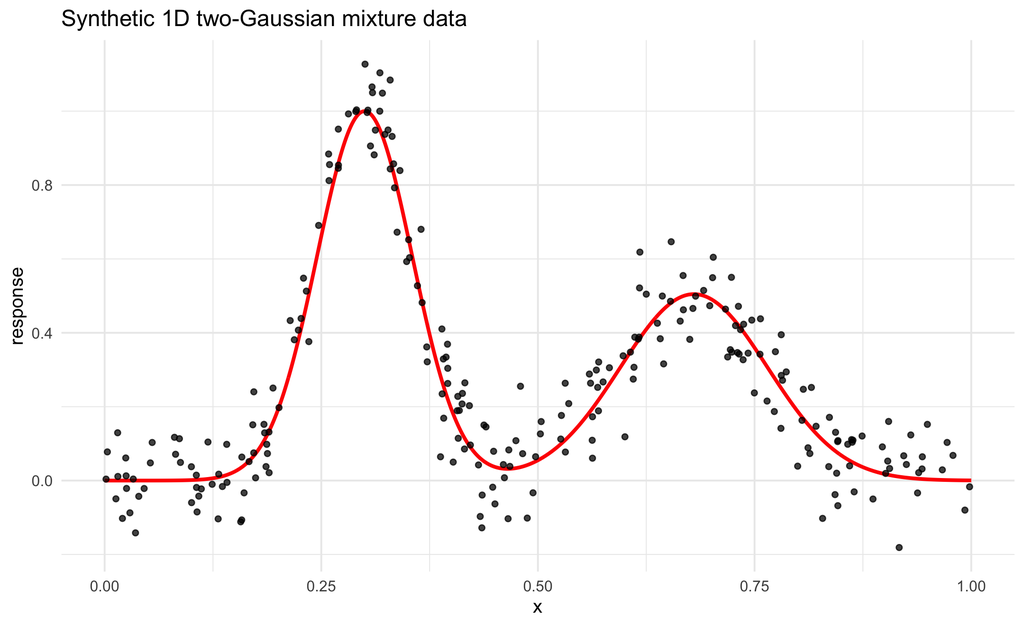

```r
raw.df <- data.frame(x = x, y = y, truth = truth)
truth.df <- data.frame(x = x.grid, truth = truth.grid)

ggplot(raw.df, aes(x, y)) +
  geom_line(data = truth.df, aes(y = truth), color = "red", linewidth = 1.1) +
  geom_point(color = "black", alpha = 0.75, size = 1.4) +
  labs(
    title = "Synthetic 1D two-Gaussian mixture data",
    x = "x",
    y = "response"
  ) +
  theme_minimal(base_size = 12)
```

## 4 Parameter Sweep

```r
inverse.grid <- expand.grid(
  conductance.rule = "inverse.length.power",
  alpha = c(0.5, 1, 2, 3),
  laplacian.type = c("unnormalized", "symmetric.normalized"),
  filter.type = c("heat_kernel", "tikhonov"),
  n.eigenpairs = c(30L, 60L),
  stringsAsFactors = FALSE
)
inverse.grid$sigma.rule <- NA_character_
inverse.grid$sigma.quantile <- NA_real_
inverse.grid$local.k <- NA_integer_

exp.grid <- expand.grid(
  conductance.rule = c("exp.length", "exp.length.squared"),
  sigma.rule = c("edge.quantile", "median"),
  sigma.quantile = c(0.5, 0.75),
  laplacian.type = c("unnormalized", "symmetric.normalized"),
  filter.type = c("heat_kernel", "tikhonov"),
  n.eigenpairs = c(30L, 60L),
  stringsAsFactors = FALSE
)
exp.grid$alpha <- NA_real_
exp.grid$local.k <- NA_integer_

self.grid <- expand.grid(
  conductance.rule = "self.tuned.gaussian",
  local.k = c(3L, 5L, 10L),
  laplacian.type = c("unnormalized", "symmetric.normalized"),
  filter.type = c("heat_kernel", "tikhonov"),
  n.eigenpairs = c(30L, 60L),
  stringsAsFactors = FALSE
)
self.grid$alpha <- NA_real_
self.grid$sigma.rule <- NA_character_
self.grid$sigma.quantile <- NA_real_

sweep.grid <- rbind(
  inverse.grid[, c("conductance.rule", "alpha", "sigma.rule", "sigma.quantile", "local.k",
                  "laplacian.type", "filter.type", "n.eigenpairs")],
  exp.grid[, c("conductance.rule", "alpha", "sigma.rule", "sigma.quantile", "local.k",
               "laplacian.type", "filter.type", "n.eigenpairs")],
  self.grid[, c("conductance.rule", "alpha", "sigma.rule", "sigma.quantile", "local.k",
                "laplacian.type", "filter.type", "n.eigenpairs")]
)
sweep.grid$n.candidates <- 30L
sweep.grid$conductance.label <- mapply(
  conductance_label,
  sweep.grid$conductance.rule,
  sweep.grid$alpha,
  sweep.grid$sigma.rule,
  sweep.grid$sigma.quantile,
  sweep.grid$local.k,
  USE.NAMES = FALSE
)
sweep.grid$label <- sprintf(
  "%03d %s %s %s eigenpairs=%d",
  seq_len(nrow(sweep.grid)),
  sweep.grid$conductance.label,
  sweep.grid$laplacian.type,
  sweep.grid$filter.type,
  sweep.grid$n.eigenpairs
)

data.frame(n.metric.fits = nrow(sweep.grid))
```

```
##   n.metric.fits
## 1           120
```

```r
metric.results <- vector("list", nrow(sweep.grid))
metric.fits <- vector("list", nrow(sweep.grid))

for (i in seq_len(nrow(sweep.grid))) {
  spec <- as.list(sweep.grid[i, ])
  fit.out <- fit_metric_one(spec, graph = graph, y = y, n = n)
  metric.fits[[i]] <- fit.out$result
  metric.results[[i]] <- cbind(
    sweep.grid[i, ],
    score_fit(
      method = "fit.metric.graph.lowpass",
      fit = fit.out$result,
      elapsed = fit.out$elapsed,
      x = x,
      y = y,
      truth = truth
    )
  )
}

metric.results <- do.call(rbind, metric.results)
metric.results$rank.rmse.truth <- rank(metric.results$rmse.truth, ties.method = "first", na.last = "keep")
metric.results <- metric.results[order(metric.results$rmse.truth), ]
rownames(metric.results) <- NULL

head(metric.results[, c(
  "rank.rmse.truth", "conductance.rule", "alpha", "sigma.rule",
  "sigma.quantile", "local.k", "laplacian.type", "filter.type",
  "n.eigenpairs", "rmse.truth", "gcv", "effective.df", "runtime.sec",
  "eigen.backend", "status"
)], 12)
```

```
##    rank.rmse.truth     conductance.rule alpha    sigma.rule sigma.quantile
## 1                1 inverse.length.power   0.5          <NA>             NA
## 2                2 inverse.length.power   0.5          <NA>             NA
## 3                3 inverse.length.power   0.5          <NA>             NA
## 4                4 inverse.length.power   1.0          <NA>             NA
## 5                5 inverse.length.power   1.0          <NA>             NA
## 6                6  self.tuned.gaussian    NA          <NA>             NA
## 7                7  self.tuned.gaussian    NA          <NA>             NA
## 8                8           exp.length    NA edge.quantile           0.75
## 9                9           exp.length    NA edge.quantile           0.75
## 10              10 inverse.length.power   0.5          <NA>             NA
## 11              11  self.tuned.gaussian    NA          <NA>             NA
## 12              12  self.tuned.gaussian    NA          <NA>             NA
##    local.k laplacian.type filter.type n.eigenpairs rmse.truth          gcv
## 1       NA   unnormalized heat_kernel           60 0.02769843 3.334876e-05
```

[output cut: 24 more lines]

## 5 rdgraph Baseline with MST Repair

```r
rd.out <- fit_rdgraph_sknn_mst_repaired(X = X, y = y, k = graph.k)
rd.fit <- rd.out$result
rd.elapsed <- rd.out$fit.elapsed

rd.result <- score_fit(
  method = "fit.rdgraph.regression",
  fit = rd.fit,
  elapsed = rd.elapsed,
  x = x,
  y = y,
  truth = truth
)
rd.result[, c("method", "status", "rmse.truth", "rmse.observed", "mae.truth",
              "runtime.sec", "eta", "gcv", "message")]
```

```
##                   method status rmse.truth rmse.observed  mae.truth runtime.sec
## 1 fit.rdgraph.regression     ok  0.0521614    0.09700377 0.04063311       0.358
##         eta          gcv message
## 1 0.1168306 4.081622e-05
```

```r
if (!is.null(rd.out$graph)) {
  data.frame(
    k = graph.k,
    graph.constructor = "create.sknn.graph",
    n.components.before.mst = rd.out$graph$n_components_before,
    n.components.after.mst = rd.out$graph$n_components_after,
    n.mst.edges.added = rd.out$graph$n_mst_edges_added,
    n.edges.before.mst = sum(lengths(rd.out$graph$raw_adj_list)) / 2,
    n.edges.after.mst = sum(lengths(rd.out$graph$adj_list)) / 2,
    graph.construction.sec = rd.out$graph.elapsed,
    rdgraph.fit.sec = rd.out$fit.elapsed
  )
} else {
  data.frame(message = "MST-repaired rdgraph construction failed")
}
```

```
##   k graph.constructor n.components.before.mst n.components.after.mst
## 1 5 create.sknn.graph                       4                      1
##   n.mst.edges.added n.edges.before.mst n.edges.after.mst graph.construction.sec
## 1                 3                739               742                  0.542
##   rdgraph.fit.sec
## 1           0.358
```

## 6 Summary

```r
best.metric <- metric.results[which.min(metric.results$rmse.truth), ]
comparison <- rbind(
  data.frame(
    family = "Best metric graph low-pass",
    method = paste(
      best.metric$conductance.rule,
      best.metric$laplacian.type,
      best.metric$filter.type,
      paste0("eigenpairs=", best.metric$n.eigenpairs)
    ),
    rmse.truth = best.metric$rmse.truth,
    rmse.observed = best.metric$rmse.observed,
    mae.truth = best.metric$mae.truth,
    runtime.sec = best.metric$runtime.sec,
    eta = best.metric$eta,
    gcv = best.metric$gcv,
    status = best.metric$status
  ),
  data.frame(
    family = "rdgraph baseline",
    method = "fit.rdgraph.regression default-style",
    rmse.truth = rd.result$rmse.truth,
    rmse.observed = rd.result$rmse.observed,
    mae.truth = rd.result$mae.truth,
    runtime.sec = rd.result$runtime.sec,
    eta = rd.result$eta,
    gcv = rd.result$gcv,
    status = rd.result$status
  )
)
comparison
```

```
##                       family
## 1 Best metric graph low-pass
## 2           rdgraph baseline
##                                                        method rmse.truth
## 1 inverse.length.power unnormalized heat_kernel eigenpairs=60 0.02769843
## 2                        fit.rdgraph.regression default-style 0.05216140
##   rmse.observed  mae.truth runtime.sec        eta          gcv status
## 1    0.08120879 0.02149697       0.114 0.06563042 3.334876e-05     ok
## 2    0.09700377 0.04063311       0.358 0.11683063 4.081622e-05     ok
```

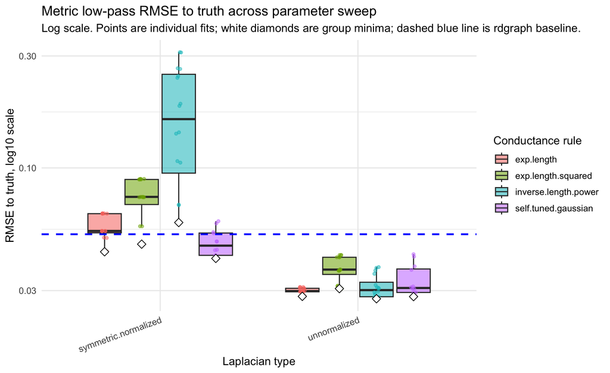

```r
ok.metric <- subset(metric.results, status == "ok")
group.min.metric <- aggregate(
  rmse.truth ~ laplacian.type + conductance.rule,
  data = ok.metric,
  FUN = min
)

ggplot(ok.metric, aes(x = laplacian.type, y = rmse.truth, fill = conductance.rule)) +
  geom_boxplot(outlier.alpha = 0.25, alpha = 0.55) +
  geom_point(
    aes(color = conductance.rule),
    position = position_jitterdodge(jitter.width = 0.08, dodge.width = 0.75),
    size = 1.25,
    alpha = 0.5,
    show.legend = FALSE
  ) +
  geom_point(
    data = group.min.metric,
    aes(x = laplacian.type, y = rmse.truth, group = conductance.rule),
    position = position_dodge(width = 0.75),
    shape = 23,
    size = 3,
    fill = "white",
    color = "black",
    inherit.aes = FALSE
  ) +
  geom_hline(yintercept = rd.result$rmse.truth, color = "blue", linewidth = 0.9, linetype = 2) +
  scale_y_log10() +
  labs(
    title = "Metric low-pass RMSE to truth across parameter sweep",
    subtitle = "Log scale. Points are individual fits; white diamonds are group minima; dashed blue line is rdgraph baseline.",
    x = "Laplacian type",
    y = "RMSE to truth, log10 scale",
    fill = "Conductance rule"
  ) +
  theme_minimal(base_size = 12) +
  theme(axis.text.x = element_text(angle = 20, hjust = 1))
```

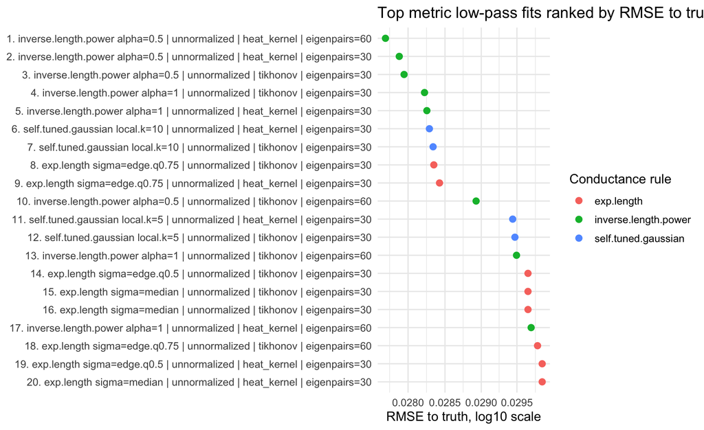

```r
top.metric.plot <- head(ok.metric[order(ok.metric$rmse.truth), ], 20)
top.metric.plot$fit.id <- factor(
  paste0(seq_len(nrow(top.metric.plot)), ". ",
         top.metric.plot$conductance.label, " | ",
         top.metric.plot$laplacian.type, " | ",
         top.metric.plot$filter.type, " | eigenpairs=",
         top.metric.plot$n.eigenpairs),
  levels = rev(paste0(seq_len(nrow(top.metric.plot)), ". ",
                      top.metric.plot$conductance.label, " | ",
                      top.metric.plot$laplacian.type, " | ",
                      top.metric.plot$filter.type, " | eigenpairs=",
                      top.metric.plot$n.eigenpairs))
)

ggplot(top.metric.plot, aes(x = rmse.truth, y = fit.id, color = conductance.rule)) +
  geom_point(size = 2.4) +
  scale_x_log10() +
  labs(
    title = "Top metric low-pass fits ranked by RMSE to truth",
    x = "RMSE to truth, log10 scale",
    y = NULL,
    color = "Conductance rule"
  ) +
  theme_minimal(base_size = 12)
```

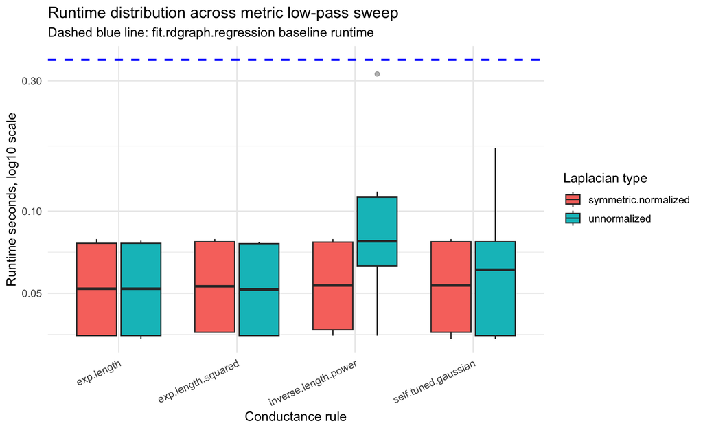

```r
ggplot(ok.metric, aes(x = conductance.rule, y = runtime.sec, fill = laplacian.type)) +
  geom_boxplot(outlier.alpha = 0.35) +
  geom_hline(yintercept = rd.result$runtime.sec, color = "blue", linewidth = 0.9, linetype = 2) +
  scale_y_log10() +
  labs(
    title = "Runtime distribution across metric low-pass sweep",
    subtitle = "Dashed blue line: fit.rdgraph.regression baseline runtime",
    x = "Conductance rule",
    y = "Runtime seconds, log10 scale",
    fill = "Laplacian type"
  ) +
  theme_minimal(base_size = 12) +
  theme(axis.text.x = element_text(angle = 25, hjust = 1))
```

## 7 Fit Curves

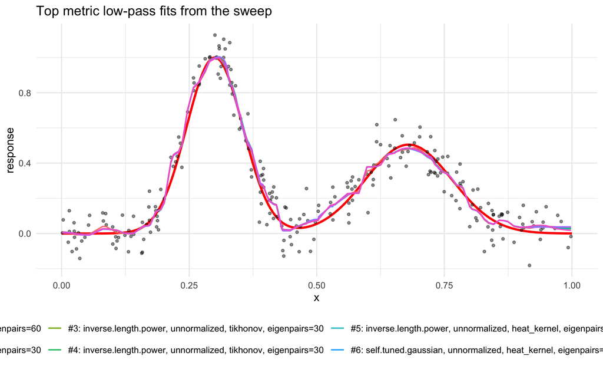

```r
top.k <- min(8L, nrow(ok.metric))
top.rows <- ok.metric[seq_len(top.k), ]
top.indices <- as.integer(sub(" .*", "", top.rows$label))

fit.curves <- do.call(rbind, lapply(seq_along(top.indices), function(j) {
  idx <- top.indices[j]
  fit <- metric.fits[[idx]]
  data.frame(
    x = x,
    fitted = fit$fitted.values,
    label = paste0("#", j, ": ", sweep.grid$conductance.rule[idx], ", ",
                   sweep.grid$laplacian.type[idx], ", ",
                   sweep.grid$filter.type[idx], ", eigenpairs=", sweep.grid$n.eigenpairs[idx])
  )
}))

rd.curve <- if (!inherits(rd.fit, "error")) {
  data.frame(x = x, fitted = rd.fit$fitted.values, label = "fit.rdgraph.regression")
} else {
  NULL
}

ggplot(raw.df, aes(x, y)) +
  geom_line(data = truth.df, aes(y = truth), color = "red", linewidth = 1.15) +
  geom_point(color = "black", alpha = 0.45, size = 1.1) +
  geom_line(data = fit.curves, aes(y = fitted, color = label), linewidth = 0.7, alpha = 0.9) +
  labs(
    title = "Top metric low-pass fits from the sweep",
    x = "x",
    y = "response",
    color = "fit"
  ) +
  theme_minimal(base_size = 12) +
  theme(legend.position = "bottom")
```

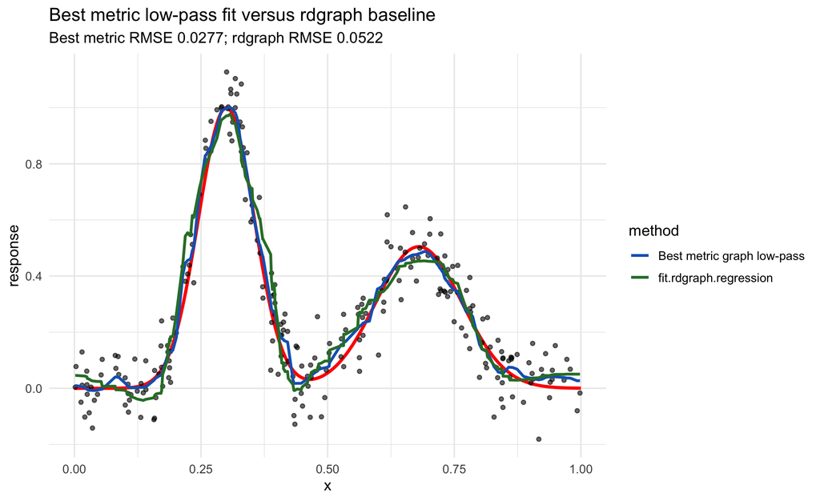

```r
best.idx <- as.integer(sub(" .*", "", best.metric$label))
best.fit <- metric.fits[[best.idx]]

plot.df <- rbind(
  data.frame(x = x, fitted = best.fit$fitted.values, method = "Best metric graph low-pass"),
  if (!is.null(rd.curve)) data.frame(x = rd.curve$x, fitted = rd.curve$fitted, method = "fit.rdgraph.regression") else NULL
)

ggplot(raw.df, aes(x, y)) +
  geom_line(data = truth.df, aes(y = truth), color = "red", linewidth = 1.2) +
  geom_point(color = "black", alpha = 0.6, size = 1.25) +
  geom_line(data = plot.df, aes(y = fitted, color = method), linewidth = 1.05) +
  scale_color_manual(values = c("Best metric graph low-pass" = "#1565c0",
                                "fit.rdgraph.regression" = "#2e7d32")) +
  labs(
    title = "Best metric low-pass fit versus rdgraph baseline",
    subtitle = sprintf(
      "Best metric RMSE %.4f; rdgraph RMSE %.4f",
      best.metric$rmse.truth,
      rd.result$rmse.truth
    ),
    x = "x",
    y = "response",
    color = "method"
  ) +
  theme_minimal(base_size = 12)
```

## 8 Conductance and Solver Diagnostics

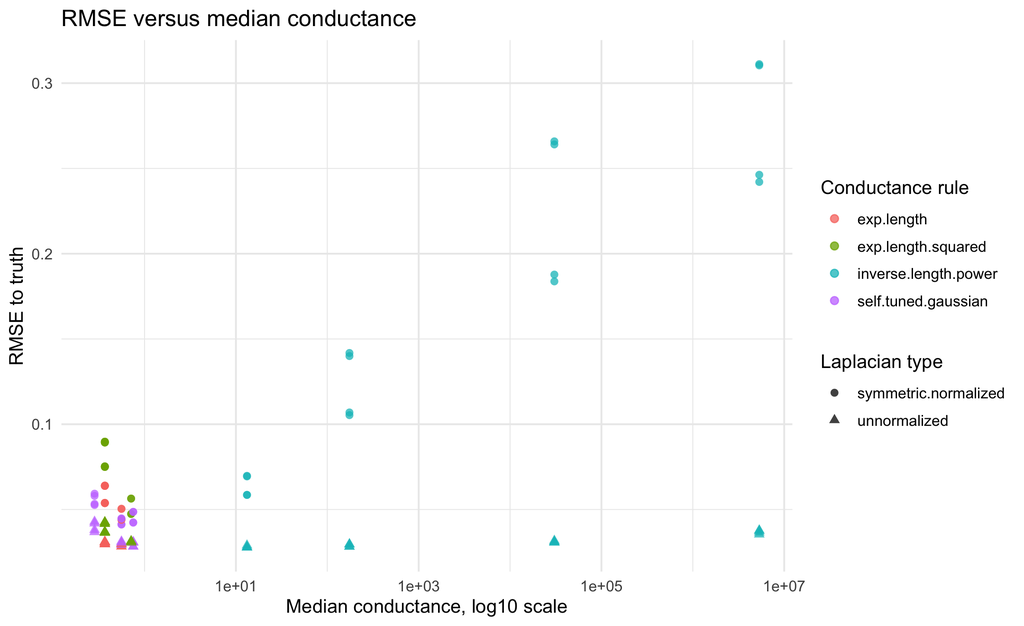

```r
ggplot(ok.metric, aes(x = conductance.median, y = rmse.truth, color = conductance.rule)) +
  geom_point(aes(shape = laplacian.type), alpha = 0.75, size = 2) +
  scale_x_log10() +
  labs(
    title = "RMSE versus median conductance",
    x = "Median conductance, log10 scale",
    y = "RMSE to truth",
    color = "Conductance rule",
    shape = "Laplacian type"
  ) +
  theme_minimal(base_size = 12)
```

```r
as.data.frame(table(ok.metric$eigen.backend, ok.metric$laplacian.type))
```

```
##           Var1                 Var2 Freq
## 1 sparse.shift symmetric.normalized   60
## 2 sparse.shift         unnormalized   60
```

## 9 Full Result Table

```r
metric.results[, c(
  "rank.rmse.truth", "conductance.rule", "alpha", "sigma.rule",
  "sigma.quantile", "local.k", "laplacian.type", "filter.type",
  "n.eigenpairs", "rmse.truth", "rmse.observed", "mae.truth",
  "runtime.sec", "eta", "gcv", "effective.df", "eigen.backend",
  "fitted.min", "fitted.max", "conductance.min", "conductance.median",
  "conductance.max", "status", "message"
)]
```

```
##     rank.rmse.truth     conductance.rule alpha    sigma.rule sigma.quantile
## 1                 1 inverse.length.power   0.5          <NA>             NA
## 2                 2 inverse.length.power   0.5          <NA>             NA
## 3                 3 inverse.length.power   0.5          <NA>             NA
## 4                 4 inverse.length.power   1.0          <NA>             NA
## 5                 5 inverse.length.power   1.0          <NA>             NA
## 6                 6  self.tuned.gaussian    NA          <NA>             NA
## 7                 7  self.tuned.gaussian    NA          <NA>             NA
## 8                 8           exp.length    NA edge.quantile           0.75
## 9                 9           exp.length    NA edge.quantile           0.75
## 10               10 inverse.length.power   0.5          <NA>             NA
## 11               11  self.tuned.gaussian    NA          <NA>             NA
## 12               12  self.tuned.gaussian    NA          <NA>             NA
## 13               13 inverse.length.power   1.0          <NA>             NA
## 14               14           exp.length    NA edge.quantile           0.50
```

[output cut: 590 more lines]